# Chapter-5-Lab

[Bruce Hartman](https://drbrucehartman.net/brucewebsite/)

Last updated: 16 January, 2025

# Introduction

Solve Chapter 5 Lab from the HEADS text.

# Packages

Regular R packages:

```r
library(tidyverse)
library(ggfortify)
library(GGally)
library(broom)
library(skimr)
library(gt)
library(patchwork)
library(yardstick)
library(car)
```

Github packages:

```r
library(devtools)
install_github("bhartman2/mbadtools")
```

```
Using GitHub PAT from the git credential store.
Skipping install of 'mbadtools' from a github remote, the SHA1 (22fd6b1c) has not changed since last install.
  Use `force = TRUE` to force installation
```

```r
library(mbadtools)
```

For this text:

```r
library(HEADS)
```

# Univariate Linear Regression (5.7.1)

Data: The data set `birthwt` is also accessible through the package `MASS`, see MASS.

```r
data(birthwt)
birthwt
```

|  | low | age | lwt | race | smoke | ptl | ht | ui | ftv | bwt |
| --- | --- | --- | --- | --- | --- | --- | --- | --- | --- | --- |
| 85 | 0 | 19 | 182 | 2 | 0 | 0 | 0 | 1 | 0 | 2523 |
| 86 | 0 | 33 | 155 | 3 | 0 | 0 | 0 | 0 | 3 | 2551 |
| 87 | 0 | 20 | 105 | 1 | 1 | 0 | 0 | 0 | 1 | 2557 |
| 88 | 0 | 21 | 108 | 1 | 1 | 0 | 0 | 1 | 2 | 2594 |
| 89 | 0 | 18 | 107 | 1 | 1 | 0 | 0 | 1 | 0 | 2600 |
| 91 | 0 | 21 | 124 | 3 | 0 | 0 | 0 | 0 | 0 | 2622 |
| 92 | 0 | 22 | 118 | 1 | 0 | 0 | 0 | 0 | 1 | 2637 |
| 93 | 0 | 17 | 103 | 3 | 0 | 0 | 0 | 0 | 1 | 2637 |
| 94 | 0 | 29 | 123 | 1 | 1 | 0 | 0 | 0 | 1 | 2663 |
| 95 | 0 | 26 | 113 | 1 | 1 | 0 | 0 | 0 | 0 | 2665 |

[output cut: 179 more lines]

```r
#perform univeriate linear regression with mother's age against birth weight
fit <- lm(bwt~age, data = birthwt)
fit
```

```
Call:
lm(formula = bwt ~ age, data = birthwt)

Coefficients:
(Intercept)          age
    2655.74        12.43
```

```r
#obtain the 95% confidence interval for the coefficients
confint(fit)
```

```
                  2.5 %     97.5 %
(Intercept) 2184.543672 3126.94527
age           -7.342539   32.20196
```

```r
## 2.5 % 97.5 %
## (Intercept) 2184.543672 3126.94527
## age -7.342539 32.20196
fit %>% tidy(conf.int = TRUE)
```

| term | estimate | std.error | statistic | p.value | conf.low | conf.high |
| --- | --- | --- | --- | --- | --- | --- |
| (Intercept) | 2655.74447 | 238.85709 | 11.118550 | 2.267545e-22 | 2184.543672 | 3126.94527 |
| age | 12.42971 | 10.02278 | 1.240146 | 2.164752e-01 | -7.342539 | 32.20196 |

```r
#predict birth weight based on the given mothers' ages
predict(fit, data.frame(age=c(25,28,50)))
```

```
       1        2        3
2966.487 3003.776 3277.230
```

```r
fit %>% summary()
```

```
Call:
lm(formula = bwt ~ age, data = birthwt)

Residuals:
     Min       1Q   Median       3Q      Max
-2294.78  -517.63    10.51   530.80  1774.92

Coefficients:
            Estimate Std. Error t value Pr(>|t|)
(Intercept)  2655.74     238.86   11.12   <2e-16 ***
age            12.43      10.02    1.24    0.216
---
Signif. codes:  0 ‘***’ 0.001 ‘**’ 0.01 ‘*’ 0.05 ‘.’ 0.1 ‘ ’ 1

Residual standard error: 728.2 on 187 degrees of freedom
Multiple R-squared:  0.008157,  Adjusted R-squared:  0.002853
F-statistic: 1.538 on 1 and 187 DF,  p-value: 0.2165
```

```r
fit %>% glance
```

| r.squared | adj.r.squared | sigma | statistic | p.value | df | logLik | AIC | BIC | deviance | df.residual | nobs |
| --- | --- | --- | --- | --- | --- | --- | --- | --- | --- | --- | --- |
| 0.008157307 | 0.002853336 | 728.1732 | 1.537962 | 0.2164752 | 1 | -1512.786 | 3031.572 | 3041.297 | 99154173 | 187 | 189 |

```r
fit %>% tidy
```

| term | estimate | std.error | statistic | p.value |
| --- | --- | --- | --- | --- |
| (Intercept) | 2655.74447 | 238.85709 | 11.118550 | 2.267545e-22 |
| age | 12.42971 | 10.02278 | 1.240146 | 2.164752e-01 |

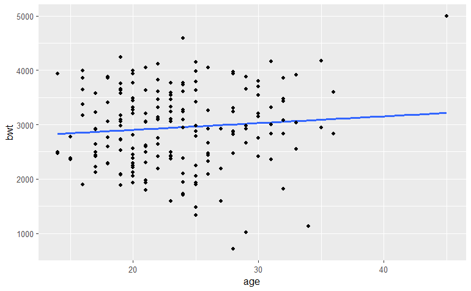

```r
#plot the graph
ggplot(birthwt, aes(x=age, y=bwt)) +
  geom_smooth(method = lm, se = FALSE, formula='y~x') +
  geom_point()
```

# Categorical Variable (5.7.2)

```r
#convert to factor variable
birthwt$race <- as.factor(birthwt$race)
```

```r
#perform univariate linear regression with race against birth weight
fit <- lm(bwt~race, data = birthwt)
summary(fit)
```

```
Call:
lm(formula = bwt ~ race, data = birthwt)

Residuals:
     Min       1Q   Median       3Q      Max
-2096.28  -502.72   -12.72   526.28  1887.28

Coefficients:
            Estimate Std. Error t value Pr(>|t|)
(Intercept)  3102.72      72.92  42.548  < 2e-16 ***
race2        -383.03     157.96  -2.425  0.01627 *
race3        -297.44     113.74  -2.615  0.00965 **
---
Signif. codes:  0 ‘***’ 0.001 ‘**’ 0.01 ‘*’ 0.05 ‘.’ 0.1 ‘ ’ 1

Residual standard error: 714.5 on 186 degrees of freedom
Multiple R-squared:  0.05017,   Adjusted R-squared:  0.03996
F-statistic: 4.913 on 2 and 186 DF,  p-value: 0.008336
```

# Multivariate Linear Regression (5.7.3)

```r
#perform multivariate linear regression with age and smoke against birth weight
fit <- lm(bwt ~ age + smoke, data = birthwt)
fit %>% summary
```

```
Call:
lm(formula = bwt ~ age + smoke, data = birthwt)

Residuals:
     Min       1Q   Median       3Q      Max
-2119.98  -442.66    52.92   532.38  1690.74

Coefficients:
            Estimate Std. Error t value Pr(>|t|)
(Intercept) 2791.224    240.950  11.584   <2e-16 ***
age           11.290      9.881   1.143    0.255
smoke       -278.356    106.987  -2.602    0.010 *
---
Signif. codes:  0 ‘***’ 0.001 ‘**’ 0.01 ‘*’ 0.05 ‘.’ 0.1 ‘ ’ 1

Residual standard error: 717.2 on 186 degrees of freedom
Multiple R-squared:  0.04299,   Adjusted R-squared:  0.0327
F-statistic: 4.177 on 2 and 186 DF,  p-value: 0.0168
```

```r
birthwt1 %>% colnames
```

```
[1] "age"   "lwt"   "race"  "smoke" "ptl"   "ht"    "ui"    "ftv"   "bwt"
```

After removing low, we can develop a multivariate linear regression model using all of the remaining variables.

```r
#perform linear regression with all the variables against birth weight
fit <- lm(bwt~., data = birthwt1)
summary(fit)
```

```
Call:
lm(formula = bwt ~ ., data = birthwt1)

Residuals:
     Min       1Q   Median       3Q      Max
-1825.26  -435.21    55.91   473.46  1701.20

Coefficients:
            Estimate Std. Error t value Pr(>|t|)
(Intercept) 2927.962    312.904   9.357  < 2e-16 ***
age           -3.570      9.620  -0.371 0.711012
lwt            4.354      1.736   2.509 0.013007 *
race2       -488.428    149.985  -3.257 0.001349 **
race3       -355.077    114.753  -3.094 0.002290 **
smoke       -352.045    106.476  -3.306 0.001142 **
ptl          -48.402    101.972  -0.475 0.635607
ht          -592.827    202.321  -2.930 0.003830 **
ui          -516.081    138.885  -3.716 0.000271 ***
ftv          -14.058     46.468  -0.303 0.762598
---
Signif. codes:  0 ‘***’ 0.001 ‘**’ 0.01 ‘*’ 0.05 ‘.’ 0.1 ‘ ’ 1

Residual standard error: 650.3 on 179 degrees of freedom
Multiple R-squared:  0.2427,    Adjusted R-squared:  0.2047
F-statistic: 6.376 on 9 and 179 DF,  p-value: 7.891e-08
```

Use a function from package `mbadtools` to display the significant ones.

```r
fit %>% tidy %>% gt_add_significance()
```

| term | estimate | std.error | statistic | p.value |
| --- | --- | --- | --- | --- |
| (Intercept) | 2927.96193690468 | 312.904260450243 | 9.35737318722216 | 3.415922305958e-17 |
| age | -3.56993439270332 | 9.6202314885427 | -0.371086121675447 | 0.711012209409099 |
| lwt | 4.35401277808284 | 1.73558566221963 | 2.50867063082009 | 0.0130072999696942 |
| race2 | -488.427538394991 | 149.984534876355 | -3.25651933912816 | 0.00134914068318471 |
| race3 | -355.077106858672 | 114.753322763293 | -3.0942642732107 | 0.00228993279415675 |
| smoke | -352.044533461501 | 106.47641964083 | -3.30631453094524 | 0.00114227679546541 |
| ptl | -48.4020342379221 | 101.971597945053 | -0.474661917762663 | 0.635606544213594 |
| ht | -592.827444311721 | 202.32115998403 | -2.93013071078929 | 0.00382976366831857 |
| ui | -516.080977414531 | 138.885352397111 | -3.71587765381418 | 0.000270520500247979 |
| ftv | -14.0580542159474 | 46.4680362673007 | -0.302531704483495 | 0.762598029227647 |

The light green ones are significant at the .05 level.

# Nonlinear Transformation of Predictor Variables (5.7.4)

```r
#perform linear regression with age and age^2
fit <- lm(bwt~age+I(age^2), data = birthwt)
summary(fit)
```

```
Call:
lm(formula = bwt ~ age + I(age^2), data = birthwt)

Residuals:
     Min       1Q   Median       3Q      Max
-2219.14  -541.47    21.68   592.53  1737.16

Coefficients:
            Estimate Std. Error t value Pr(>|t|)
(Intercept) 4605.173    817.736   5.632 6.51e-08 ***
age         -150.858     66.331  -2.274   0.0241 *
I(age^2)       3.249      1.305   2.490   0.0137 *
---
Signif. codes:  0 ‘***’ 0.001 ‘**’ 0.01 ‘*’ 0.05 ‘.’ 0.1 ‘ ’ 1

Residual standard error: 718.3 on 186 degrees of freedom
Multiple R-squared:  0.04014,   Adjusted R-squared:  0.02982
F-statistic: 3.889 on 2 and 186 DF,  p-value: 0.02215
```

```r
#perform linear regression with sixth degree polynomial with respect to age
fit <- lm(bwt~poly(age,6), data = birthwt)
summary(fit)
```

```
Call:
lm(formula = bwt ~ poly(age, 6), data = birthwt)

Residuals:
     Min       1Q   Median       3Q      Max
-2186.17  -503.78    31.38   554.50  1735.92

Coefficients:
              Estimate Std. Error t value Pr(>|t|)
(Intercept)    2944.59      52.51  56.074   <2e-16 ***
poly(age, 6)1   903.04     721.93   1.251   0.2126
poly(age, 6)2  1788.11     721.93   2.477   0.0142 *
poly(age, 6)3   913.46     721.93   1.265   0.2074
poly(age, 6)4   -50.23     721.93  -0.070   0.9446
poly(age, 6)5   360.50     721.93   0.499   0.6181
poly(age, 6)6   368.68     721.93   0.511   0.6102
---
Signif. codes:  0 ‘***’ 0.001 ‘**’ 0.01 ‘*’ 0.05 ‘.’ 0.1 ‘ ’ 1

Residual standard error: 721.9 on 182 degrees of freedom
Multiple R-squared:  0.05117,   Adjusted R-squared:  0.01989
F-statistic: 1.636 on 6 and 182 DF,  p-value: 0.1395
```

Only the quadratic term is significant at the .05 level.

# Variable Selection (5.7.5)

In order to perform stepwise selection, we need to load the package `leaps` leaps. After loading this library, we use the `regsubsets()` function to either perform forward or backward stepwise selection.

```r
library(leaps)
#forward selection
fit.fwd <- regsubsets(bwt~., data = birthwt1, method = "forward")
#backward selection
fit.bwd <- regsubsets(bwt~., data = birthwt1, method = "backward")

#summary of forward stepwise selection
fwd.summary <- summary(fit.fwd)
fwd.summary$outmat
```

```
         age lwt race2 race3 smoke ptl ht  ui  ftv
1  ( 1 ) " " " " " "   " "   " "   " " " " "*" " "
2  ( 1 ) " " " " " "   " "   " "   " " "*" "*" " "
3  ( 1 ) " " "*" " "   " "   " "   " " "*" "*" " "
4  ( 1 ) " " "*" "*"   " "   " "   " " "*" "*" " "
5  ( 1 ) " " "*" "*"   " "   "*"   " " "*" "*" " "
6  ( 1 ) " " "*" "*"   "*"   "*"   " " "*" "*" " "
7  ( 1 ) " " "*" "*"   "*"   "*"   "*" "*" "*" " "
8  ( 1 ) "*" "*" "*"   "*"   "*"   "*" "*" "*" " "
```

```r
#summary of backward stepwise selection
bwd.summary <- summary(fit.bwd)
bwd.summary$outmat
```

```
         age lwt race2 race3 smoke ptl ht  ui  ftv
1  ( 1 ) " " " " " "   " "   " "   " " " " "*" " "
2  ( 1 ) " " " " " "   " "   "*"   " " " " "*" " "
3  ( 1 ) " " " " " "   "*"   "*"   " " " " "*" " "
4  ( 1 ) " " " " "*"   "*"   "*"   " " " " "*" " "
5  ( 1 ) " " " " "*"   "*"   "*"   " " "*" "*" " "
6  ( 1 ) " " "*" "*"   "*"   "*"   " " "*" "*" " "
7  ( 1 ) " " "*" "*"   "*"   "*"   "*" "*" "*" " "
8  ( 1 ) "*" "*" "*"   "*"   "*"   "*" "*" "*" " "
```

For forward selection, we see that the first variable included in the model is ui, which is indicated by “*”. After that, ht is included in the model in the next iteration. For backward selection, ftv is removed from the full model in the first iteration and then age in the next iteration as indicated by “*” being not present.

Best model: AIC can be computed from Cp (Cp) and BIC

```r
#list C_p for forward stepwise selection models
fwd.summary$cp
```

```
[1] 32.324944 26.846910 20.437098 16.188749 12.027920  4.556107  6.278594  8.091525
```

```r
bwd.summary$cp
```

```
[1] 32.324944 27.239324 20.597872 12.691264  8.879389  4.556107  6.278594  8.091525
```

```r
#list BIC for forward stepwise selection models
fwd.summary$bic
```

```
[1]  -5.401968  -6.778133  -9.266694  -9.980362 -10.800281 -15.274455 -10.325044  -5.280612
```

```r
#list BIC for backward stepwise selection models
bwd.summary$bic
```

```
[1]  -5.401968  -6.425033  -9.115907 -13.397662 -13.974859 -15.274455 -10.325044  -5.280612
```

```r
#identify model with the lowest C_p
which.min(fwd.summary$cp)
```

```
[1] 6
```

```r
which.min(bwd.summary$cp)
```

```
[1] 6
```

```r
#identify model with the lowest BIC
which.min(fwd.summary$bic)
```

```
[1] 6
```

```r
which.min(bwd.summary$bic)
```

```
[1] 6
```

```r
fwd.summary$outmat[6,]
```

```
  age   lwt race2 race3 smoke   ptl    ht    ui   ftv
  " "   "*"   "*"   "*"   "*"   " "   "*"   "*"   " "
```

```r
bwd.summary$outmat[6,]
```

```
  age   lwt race2 race3 smoke   ptl    ht    ui   ftv
  " "   "*"   "*"   "*"   "*"   " "   "*"   "*"   " "
```

Both techniques choose the same 6 variables.

Coefficients:

```r
fit.fwd %>% coef(6)
```

```
(Intercept)         lwt       race2       race3       smoke          ht          ui
 2837.26392     4.24155  -475.05760  -348.15038  -356.32095  -585.19312  -525.52390
```

```r
fit.bwd %>% coef(6)
```

```
(Intercept)         lwt       race2       race3       smoke          ht          ui
 2837.26392     4.24155  -475.05760  -348.15038  -356.32095  -585.19312  -525.52390
```

The two searches found the same regression. This is unusual!!!! One of the issues with selection this way is the different methods may find different answers! How do you explain that to a customer?

# LASSO Regression

Prepare for `glmnet`:

```r
library(glmnet)
#subset for x and y
x <- subset(birthwt1, select = -bwt)
y <- subset(birthwt1, select = bwt)
#format as matrices
x <- model.matrix(~., x)
y <- as.matrix(y)
```

```r
#perform lasso with lambda = 15; lasso has alpha=1
fit <- glmnet(x,y, alpha = 1, lambda = 15)
fit$beta
```

```
10 x 1 sparse Matrix of class "dgCMatrix"
                    s0
(Intercept)    .
age            .
lwt            3.65451
race2       -402.06003
race3       -294.27825
smoke       -305.18084
ptl          -38.58150
ht          -509.18039
ui          -479.61663
ftv            .
```

Intercept, `age` and `ftv` are left out!

Prediction:

```r
#subset for an observation
obs1 <- model.matrix(~., birthwt1[1,-9])
obs1
```

```
   (Intercept) age lwt race2 race3 smoke ptl ht ui ftv
85           1  19 182     1     0     0   0  0  1   0
attr(,"assign")
 [1] 0 1 2 3 3 4 5 6 7 8
attr(,"contrasts")
attr(,"contrasts")$race
[1] "contr.treatment"
```

```r
#predict on the observation
predict(fit, newx = obs1)
```

```
         s0
85 2643.678
```

# Segmented Time Series Analysis (5.7.6)

This uses a dataset from package MASS.

```r
data(drivers, package="MASS")
drivers %>% glimpse
```

```
 Time-Series [1:192] from 1969 to 1985: 1687 1508 1507 1385 1632 ...
```

```r
#subset the drivers data and convert to dataframe
d <- drivers[145:192]
d <- as.data.frame(d)
#create three variables
d$t <- 1:48
d$ind <- 0
d$ind[26:48] <- 1
d$t2 <- pmax(d$t-25,0)
d %>% glimpse
```

```
Rows: 48
Columns: 4
$ d   <dbl> 1474, 1458, 1542, 1404, 1522, 1385, 1641, 1510, 1681, 1938, 1868, 1726, 1456, 144…
$ t   <int> 1, 2, 3, 4, 5, 6, 7, 8, 9, 10, 11, 12, 13, 14, 15, 16, 17, 18, 19, 20, 21, 22, 23…
$ ind <dbl> 0, 0, 0, 0, 0, 0, 0, 0, 0, 0, 0, 0, 0, 0, 0, 0, 0, 0, 0, 0, 0, 0, 0, 0, 0, 1, 1, …
$ t2  <dbl> 0, 0, 0, 0, 0, 0, 0, 0, 0, 0, 0, 0, 0, 0, 0, 0, 0, 0, 0, 0, 0, 0, 0, 0, 0, 1, 2, …
```

```r
#fit time series
fit <- lm(d~t+ind+t2, data=d)
summary(fit)
```

```
Call:
lm(formula = d ~ t + ind + t2, data = d)

Residuals:
   Min     1Q Median     3Q    Max
-271.5 -144.7  -23.1  123.2  366.3

Coefficients:
            Estimate Std. Error t value Pr(>|t|)
(Intercept) 1463.760     72.898  20.079  < 2e-16 ***
t             10.797      4.904   2.202    0.033 *
ind         -623.719    102.568  -6.081 2.57e-07 ***
t2             6.847      7.412   0.924    0.361
---
Signif. codes:  0 ‘***’ 0.001 ‘**’ 0.01 ‘*’ 0.05 ‘.’ 0.1 ‘ ’ 1

Residual standard error: 176.8 on 44 degrees of freedom
Multiple R-squared:  0.5083,    Adjusted R-squared:  0.4748
F-statistic: 15.16 on 3 and 44 DF,  p-value: 6.449e-07
```

> According to the summary, the number of deaths or severe injuries dropped by about 623.72 on average per month. If the significance level is set to α = 0.05, then the reduction in the number of deaths or injuries is statistically significant since the corresponding p-value for βˆ2 is 2.57×10−7.

# References

Mehrotra, Sanjay, Kevin Bui, and Hari Balasubramanian (2024). Healthcare Engineering, Analytics, and Decision Sciences: An Introduction. December 11, 2024. (https://sites.google.com/view/healthcareengineering/)

Modern Applied Statistics with S (MASS) (2002) Modern Applied Statistics with S. Fourth Edition by W. N. Venables and B. D. Ripley. Springer. ISBN 0-387-95457-0, 2002.(http://www.stats.ox.ac.uk/pub/MASS4/)

Thomas Lumley. (2024) Package ‘leaps’. (https://cran.r-project.org/web/packages/leaps/leaps.pdf)